**Research Question:** "When people in long-COVID and ME/CFS forums talk about garlic, are they describing one treatment—or several different stories, risks, and experiences?"

# Garlic means two very different things in long-COVID forums

**Abstract.** We reviewed a model-assisted extraction of garlic discussions from 1,928 Reddit accounts in long-COVID and ME/CFS communities. The clearest finding is that “garlic” does not describe one shared treatment story: one group discusses taking it, while another discusses it as a trigger food, and their framing differs sharply even after correcting an overstated result in an earlier analysis. A separate safety signal deserves attention: 113 of 640 use-reporting accounts also mentioned a blood thinner or clot-targeting enzyme in their garlic-related text, while explicit warnings were rare. The practical recommendation is to treat these posts as evidence about community beliefs and reporting gaps—not as evidence that garlic works—and to discuss possible bleeding interactions with a clinician.

**Plain-language verdict:** This dataset reveals distinct ways people *talk about* garlic, plus a potentially important safety-communication gap. It cannot tell us whether garlic treats long COVID or how often it causes harm.

## 1. What we looked at

The study began with every non-bot account whose text matched *garlic*, *allicin*, or *Kyolic*. It did not begin with people already classified as taking garlic, because that would exclude discussions of trigger foods, recipes, questions, and warnings.

1,928

accounts in the garlic cohort

1,927

accounts successfully processed

640

accounts reporting personal use

914

accounts with a garlic belief

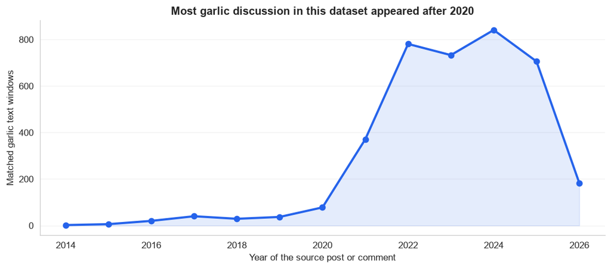

**Data coverage.** Data covers: 2014-10-20 to 2026-06-10 (140 months). 94% of matched, date-linked text windows are from 2021–2026. Dates describe when people posted, not when a treatment started or ended.

**What this means:** This is a study of how a community discusses garlic, not a 1,928-person treatment trial. The same account can discuss taking garlic, avoiding it, cooking with it, or asking about it at different times.

## 2. One word, two different worlds

The earlier v1 notebook reported an enormous split between people whose posts looked like trigger-food lists and people whose posts looked like personal treatment use. But the model assigned both the post type and the pro/anti framing in the same pass, which inflated the contrast. The v2 analysis corrected this by taking the group label from one claim and the pro/anti framing from a different claim by the same account.

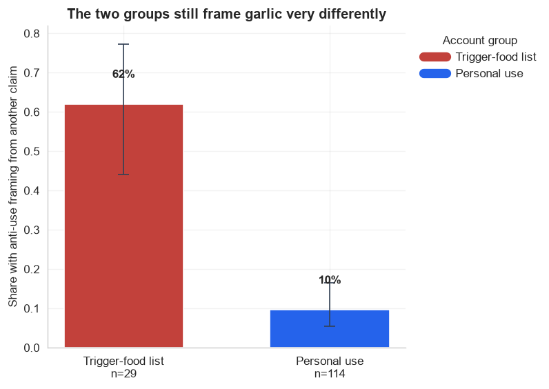

The denominator is deliberately small: an account needed a second, different claim from which to read framing.

| Group | Anti-use framing | Accounts with an independent framing claim | Share |
| --- | --- | --- | --- |
| Trigger-food-list accounts | 18 | 29 | 62.1% |
| Personal-use accounts | 11 | 114 | 9.6% |

**Plain-language verdict.** Anti-use framing appeared for 18/29 trigger-food-list accounts (62%) and 11/114 personal-use accounts (10%). The split is real in this sample, but its exact size is uncertain.

**Formal comparison.** Fisher’s exact test: odds ratio 15.3 (95% CI 5.8–40.6), p = 1.38e-08; Cohen’s h = 1.18. *Caution: the trigger-food group has only 29 eligible accounts, so the direction is more trustworthy than the point estimate.*

Examples of the explanations attached to each side. These are community claims, not verified biological mechanisms.

| Community explanation | Mostly framed as | Accounts | In that framing |
| --- | --- | --- | --- |
| Antimicrobial action | Pro-use | 220 | 195 |
| Blood flow / clotting | Pro-use | 165 | 126 |
| Allium intolerance | Anti-use | 74 | 67 |
| Histamine / MCAS trigger | Anti-use | 42 | 31 |

**Why the split makes sense:** The two sides are usually not arguing over the same mechanism. Pro-use posts tend to describe antimicrobial, gut, immune, or blood-flow ideas. Anti-use posts tend to describe histamine reactions or intolerance to alliums (the plant family that includes garlic and onions).

**Sensitivity check:** The finding survives the independence check that removed the original same-claim circularity. Its estimated odds ratio falls from 38.8 in v1 to 15.3 in v2, so the corrected result should replace the old headline.

## 3. The search method can reverse the story

Before this study, a separate automated pass had already marked 500 accounts as having a garlic-related treatment field. Full-text search found another 1,427 processed accounts. If we used only the treatment field, the community would look overwhelmingly like people taking garlic. The full-text group contains much more food-list, recipe, and symptom discussion.

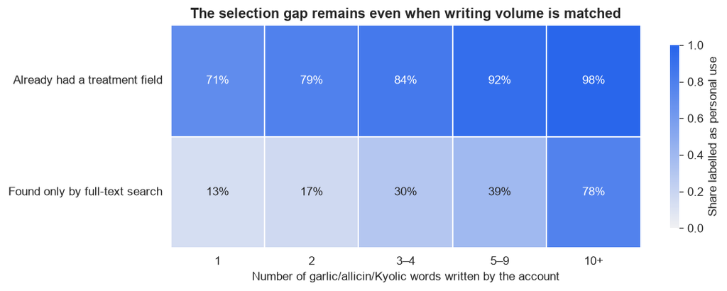

Each row is a separate Fisher exact test. All five remain significant after Benjamini–Hochberg false-discovery-rate correction.

| Garlic words written | Treatment-field n | Full-text n | Odds ratio | Fisher p | FDR-adjusted p | Cohen's h |
| --- | --- | --- | --- | --- | --- | --- |
| 1 | 206 | 978 | 15.6 | 5.70e-60 | 2.85e-59 | 1.25 |
| 2 | 94 | 233 | 18.4 | 3.10e-26 | 7.74e-26 | 1.34 |
| 3–4 | 89 | 137 | 12.5 | 3.78e-16 | 6.30e-16 | 1.17 |
| 5–9 | 66 | 61 | 18.8 | 8.55e-11 | 1.07e-10 | 1.23 |
| 10+ | 45 | 18 | 12.6 | 0.021 | 0.021 | 0.68 |

**Plain-language verdict.** The odds ratio stays between 12.5 and 18.8 in every writing-volume band. The earlier treatment field was not merely finding people who wrote more about garlic; it was selecting one kind of garlic story.

**Why this matters beyond garlic:** A database column called “treatment” can quietly encode a judgment about what counts as treatment. Researchers who build a cohort from that column may exclude people describing harms, trigger foods, uncertainty, or failed attempts before the analysis even begins.

**Sensitivity check:** The conclusion holds in every band from one garlic-related word to ten or more. Among accounts that used the word exactly once, 70.9% of those already carrying a treatment field were labelled as personal use, versus 13.5% of accounts found only by full-text search.

## 4. Counterintuitive findings worth investigating

Two findings did not fit the original study design. First, garlic was often discussed alongside medicines or enzymes used to affect clotting. Second, some “food-list” text was not about histamine or avoidance at all—it was about long-COVID smell and taste distortion (parosmia or anosmia).

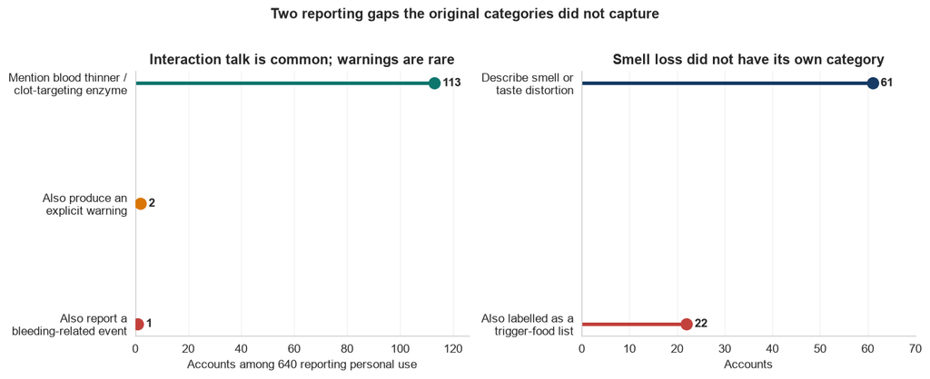

**Safety signal—not a measured interaction rate.** 113/640 use-reporting accounts (17.7%) also mention an anticoagulant or clot-targeting enzyme in their garlic-related text. Only 2 produce an explicit warning claim, and 1 report a bleeding-related event.

**Formal comparison.** Co-mention occurred in 113/640 personal-use accounts versus 52/1287 other accounts. Fisher’s exact test: odds ratio 5.09 (95% CI 3.61–7.18), p = 5.51e-22; Cohen’s h = 0.46. *Co-mention does not prove co-ingestion.*

**Sensitivity check.** After dropping the three accounts with the most extracted claims, the association remains: odds ratio 5.05, p = 1.01e-21. Conclusion holds.

**Missing category.** 61 accounts describe smell or taste distortion, and 22 of them are also labelled as trigger-food-list accounts. This regex-based finding is preliminary, but it shows how “garlic tastes wrong now” can be mistaken for “garlic triggers symptoms.”

### A quick reality check on “did it help?”

Among the 640 accounts labelled as personal users, more than half did not specify the form of garlic (330 accounts). The most common stated forms were raw cloves (168), allicin supplements (104), and the “crush and wait” preparation ritual (33).

Only 301 of the 640 personal-use accounts produced any extractable outcome. Within that highly selected subset, 215 described help only, 32 worsening only, 25 no effect only, and 29 mixed or conflicting results. Separately, 106 of 640 mentioned at least one adverse event, 18 explicitly denied one, and the large remainder said nothing about side effects.

Those numbers are interesting descriptions of posting behavior, but they are not an effectiveness or side-effect rate. People who choose to post an outcome differ from people who stay silent; positive labels are known to be over-called by roughly 10–20%; and posts naming several treatments can wrongly assign the shared outcome to garlic. A reporting-based number-needed-to-treat analog is therefore not valid here.

## 5. What patients are saying

To protect privacy, the examples below are **redacted paraphrases** of structured extraction labels, not searchable quotations. Dates refer to the source post or comment. Each example names a form and an outcome; the final two deliberately complicate the positive examples.

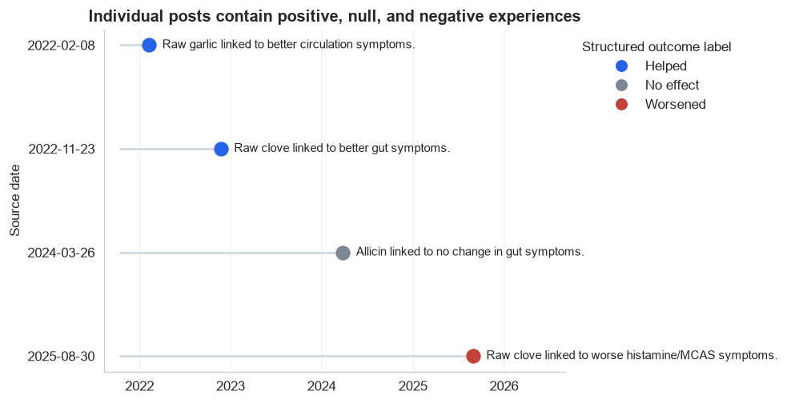

**2022-02-08 · Helped**  
A raw-garlic user linked it to improvement in a circulation-related symptom.

**2022-11-23 · Helped**  
A raw-clove user described improvement in a gut-related symptom.

**2024-03-26 · No effect**  
An allicin-supplement user reported no improvement in a gut-related symptom.

**2025-08-30 · Worsened**  
A raw-clove user described worsening of a histamine/MCAS-related symptom.

## 6. What is solid enough to act on

These recommendations concern **how to interpret and study the dataset**, not whether to take garlic. “Strong” requires a sizeable, statistically supported result; “Moderate” indicates a clear signal with an important measurement limitation; “Preliminary” means the finding is mainly a reason to improve the next analysis.

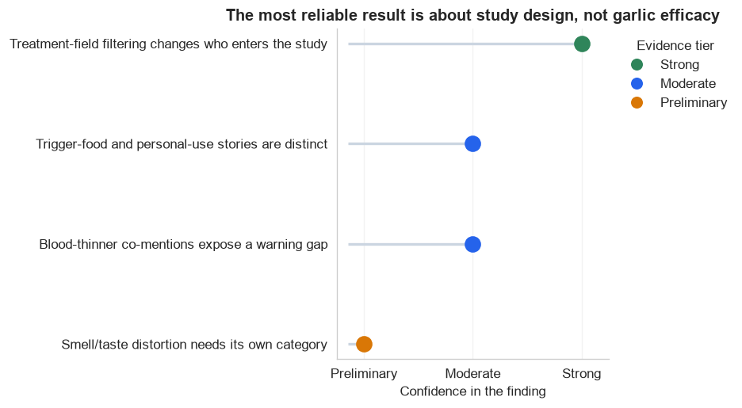

### Conclusion

Garlic is not one story in these communities. It is simultaneously a folk treatment, a trigger food, a cooking ingredient, a marker of smell loss, and part of a clot-focused supplement conversation. Collapsing all of that into a single “garlic outcome” would misrepresent both the people posting and the data.

The strongest lesson is methodological: deciding who counts as a “treatment user” can determine the conclusion before any statistics are run. Full-text retrieval exposed a large part of the conversation that the earlier treatment field omitted. The corrected analysis still finds a major divide between trigger-food and personal-use accounts, but it is smaller and less precise than v1 claimed.

For a patient, this analysis does **not** support starting garlic for long COVID. It does support one cautious action: anyone combining garlic with aspirin, prescription blood thinners, nattokinase, serrapeptase, or similar products should discuss bleeding risk with a qualified clinician. For researchers, the next step should be to add a smell/taste-distortion category, adjudicate the weak food-list boundary, and preserve the full conversation instead of beginning with a preselected treatment cohort.

### Research limitations

| Bias or limitation | How it affects this notebook |
| --- | --- |
| **Selection bias** | Reddit users who mention garlic are not representative of patients with long COVID or ME/CFS. |
| **Reporting bias** | People choose what to post; unusual successes, failures, and worries may be overrepresented. |
| **Survivorship bias** | Accounts and posts that remain available may differ from deleted or inactive material. |
| **Recall bias** | Posts may describe experiences remembered after the fact rather than recorded prospectively. |
| **Confounding** | Diet, illness severity, other supplements, and medications can explain observed patterns. |
| **No control group** | There is no untreated comparison, randomization, or verified exposure. |
| **Sentiment versus efficacy** | A positive or negative text label is not a clinical outcome measurement. |
| **Temporal snapshot** | The source ends in June 2026 and posting dates do not establish treatment timing. |
| **Positive over-call** | Validation suggests roughly 10–20% of stored positive labels may be false positives; negative labels are more reliable. |
| **Group-attribution inflation** | A post naming several treatments can assign one shared outcome to each item, including garlic. |
| **Extractor instability** | On a small temperature-zero repeat, `speech_act` matched only 79.4% of paired claims. |
| **Weak category gate** | Blind review agreed on only 5 of 12 sampled food-list/avoidance/culinary labels; those cuts remain provisional. |

The anticoagulant and parosmia follow-ups were targeted analyses prompted by v1, not a broad scan of every possible keyword. Their p-values are unadjusted and the parosmia result is explicitly hypothesis-generating.

Provenance for reproducing this public-facing synthesis.

| Provenance item | Value |
| --- | --- |
| Database | garlic_pharmacology.db |
| Database SHA-256 | 7caae438b3512ea0cb4a59f2956d3417b0b7abfde34a234dfab3e7b3d32eb4f0 |
| Pinned run ID | c05891b6ecad47900230eb606afbb230a9867fc9f41d1d2b88ec0292a05b03df |
| Cohort-member rows | 1,928 |
| Unit rows | 1,996 |
| Claim rows | 3,723 |
| Source-window rows | 3,873 |
| Source date range | 2014-10-20 to 2026-06-10 |
| Research-assistant skill | v2 |
| Notebook executed (UTC) | 2026-08-13 |

These findings reflect reporting patterns in online communities, not population-level treatment effects. This is not medical advice.